# PL Injuries Data Prep

Tamas Koncz

July 1, 2018

```r
injuries <- injuries_raw %>%
                  select(Date,                 `Game week`,      `Kick-off`,        mid,
                         pid,                  `First name`,     `Last name`,       minutes,
                         injured,               injury_length,    injury_type,
                         `Country of birth`,    Nationality,     `Date of birth`,
                         Position,              Foot,             Height,           Weight,
                         starts_with("all_"),   starts_with("pl_"))

injuries %>% glimpse()
```

```
## Observations: 150,704
## Variables: 34
## $ Date               <chr> "2013-08-17", "2013-08-17", "2013-08-17", "...
## $ `Game week`        <dbl> 1, 1, 1, 1, 1, 1, 1, 1, 1, 1, 1, 1, 1, 1, 1...
## $ `Kick-off`         <chr> "16:00", "16:00", "16:00", "16:00", "16:00"...
## $ mid                <dbl> 1483415, 1483415, 1483415, 1483415, 1483415...
## $ pid                <int> 4, 619, 1239, 2576, 2795, 2833, 2897, 2916,...
## $ `First name`       <chr> "Maarten", "Derek", "StÃ©phane", "Steve", "...
## $ `Last name`        <chr> "Stekelenburg", "Owusu Boateng", "SessÃ¨gno...
## $ minutes            <dbl> 76, 65, 72, 90, 90, 90, 90, 90, 20, 90, 90,...
## $ injured            <int> 1, 0, 0, 0, 0, 0, 0, 0, 1, 0, 0, 0, 0, 0, 0...
## $ injury_length      <int> 61, 0, 0, 0, 0, 0, 0, 0, 26, 0, 0, 0, 0, 0,...
## $ injury_type        <chr> "Shoulder Injury", "0", "0", "0", "0", "0",...
## $ `Country of birth` <chr> "Netherlands", "Ghana", "Benin", "England",...
## $ Nationality        <chr> "Netherlands", "Ghana", "Benin", "England",...
```

[output cut: 21 more lines]

Formatting clean-up for date variables

```r
injuries <- injuries %>%
              mutate(Date = as.Date(Date, "%Y-%m-%d"),
                     `Date of birth` = as.Date(`Date of birth`, "%Y-%m-%d")) %>%
              mutate(age_in_years = time_length(difftime(Date, `Date of birth`), "years"))
```

As shown, the injury data is only complete for 2010-2017. That should be still plenty for statistical analysis.

```r
f_sec_scale <- function(x) sprintf("%.2f", x)
```

```r
f_breakdown_by_bins <- function(df, s) {
  max_injury_rate_pct  <- df$injury_rate_pct %>% max()
  max_game_count       <- df$game_count      %>% max()

  ggplot(data = df, aes_string(x = s)) +
    geom_bar(aes(y = game_count, fill = "# of games"), stat= "identity") +
    geom_point(aes(y = injury_rate_pct * (max_game_count / max_injury_rate_pct), color = "% of injured"), stat= "identity") +
    geom_line( aes(y = injury_rate_pct * (max_game_count / max_injury_rate_pct), color = "% of injured"), stat= "identity", group = 1) +
    scale_y_continuous(sec.axis = sec_axis(~./(max_game_count / max_injury_rate_pct), name = "% of injured", labels = f_sec_scale),
                     labels = scales::comma) +
  scale_fill_manual(name = "Legend", values = c("# of games" = "lightblue")) +
  scale_color_manual(name = element_blank(), values = c("% of injured" = "darkblue")) +
  labs(y = "# of games", x = s, title = "Hamstring injuries happening during the game") +
  theme_minimal()
  ##TODO: legend clean-up
}
```

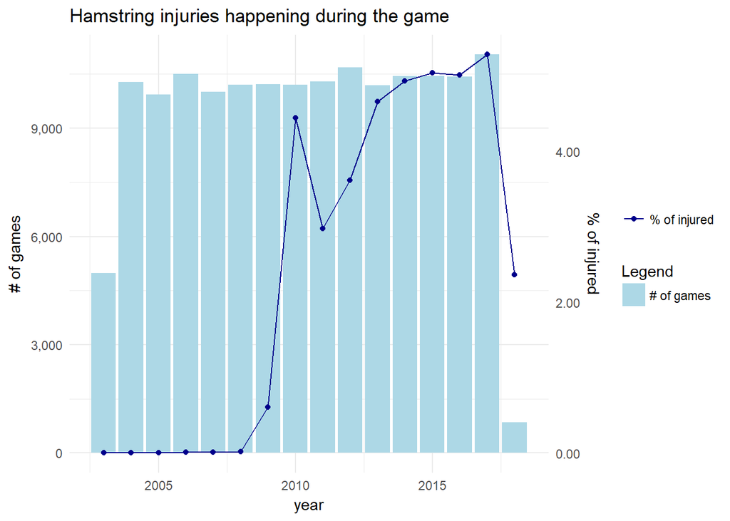

```r
injuries %>%
  mutate(year = year(Date)) %>%
  group_by(year) %>%
  summarize(game_count = n(),
  injury_count = (sum(injury_type != 0))) %>%
  ungroup() %>%
  mutate(injury_rate_pct = injury_count / game_count * 100) %>%
  f_breakdown_by_bins(s = "year")
```

```r
injuries <- injuries %>%
              filter(year(Date) %in% c(2010:2017))
```

And for height & weight

```r
injuries <- injuries %>%
              filter(!(is.null(Height) | Height == "")) %>%
              mutate(`Height (cm)` = gsub(pattern = " cm", replacement = "", x = Height)) %>%
              mutate(`Height (cm)` = as.numeric(`Height (cm)`)) %>%
              select(everything(), -Height)

injuries <- injuries %>%
              filter(!(is.null(Weight) | Weight == "")) %>%
              mutate(`Weight (kg)` = gsub(pattern = " kg", replacement = "", x = Weight)) %>%
              mutate(`Weight (kg)` = as.numeric(`Weight (kg)`)) %>%
              select(everything(), -Weight)
```

Add BMI column:

```r
injuries <- injuries %>%
              mutate(bmi = `Weight (kg)` / (`Height (cm)` / 100)^2)
```

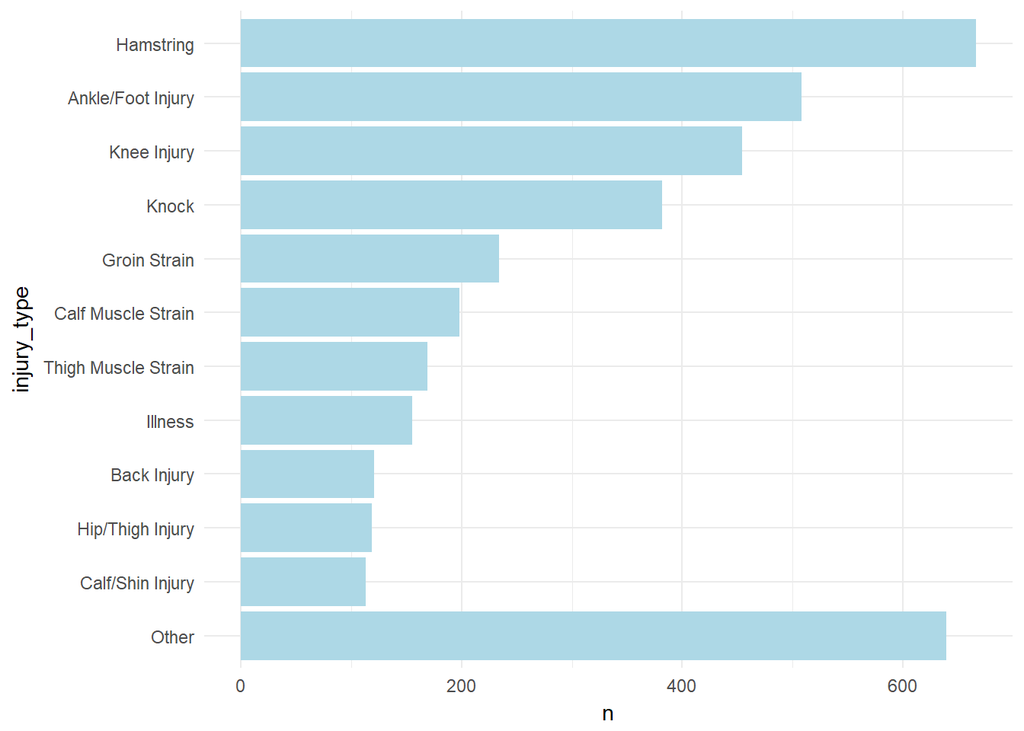

```r
injuries %>%
  filter(injury_type != '0') %>%
  count(injury_type, sort = T) %>%
  mutate(injury_type = ifelse(n<100, 'Other', injury_type)) %>%
  mutate(injury_type = reorder(injury_type, n)) %>%
  ggplot(aes(x = injury_type, y = n)) +
    geom_bar(stat = "identity", fill = "lightblue") +
    coord_flip() +
    theme_minimal()
```

Visualizing injury lengths distributions:

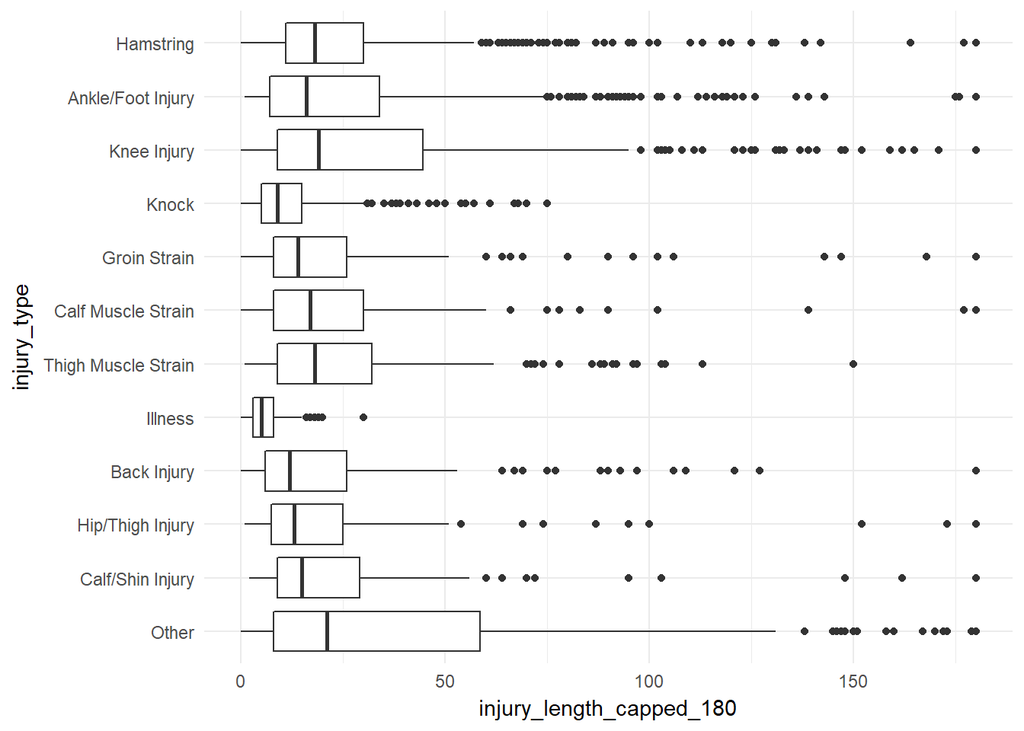

```r
injuries %>%
  filter(injury_type != '0') %>%
  group_by(injury_type) %>%
  mutate(n = n()) %>%
  ungroup() %>%
  mutate(injury_type = ifelse(n < 100, 'Other', injury_type)) %>%
  mutate(injury_type = reorder(injury_type, n)) %>%
  mutate(injury_length_capped_180 = ifelse(injury_length > 180, 180, injury_length)) %>%
  ggplot(aes(x = injury_type, y = injury_length_capped_180)) +
    geom_boxplot() +
    coord_flip() +
    theme_minimal()
```

For now, focus on ‘Hamstring’, then see if it can be extended to all strains. (Note: at the time of writing this - https://www.bbc.com/sport/football/44671242)

```r
hamstring <- injuries %>%
               filter(injury_type == "Hamstring")
```

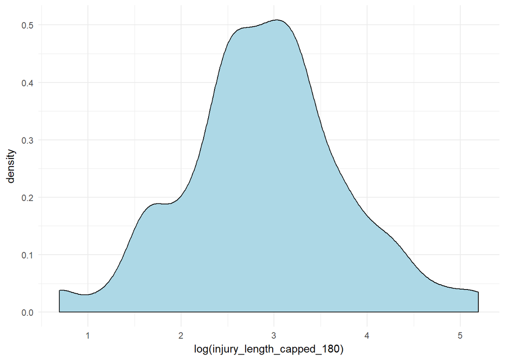

```r
hamstring %>%
  filter(injury_length > 1) %>% #should miss at least 1 day
  mutate(injury_length_capped_180 = ifelse(injury_length >= 180, 180, injury_length)) %>%
  ggplot(aes(x = log(injury_length_capped_180))) +
    geom_density(fill = "lightblue") +
    theme_minimal()
```

```r
hamstring_only <- injuries %>%
                    filter(injury_type == "0" | injury_type == "Hamstring")

#keep only injuries with "significant" missed time
hamstring_only <- hamstring_only %>%
                    filter(!(injury_type == "Hamstring" & injury_length < 7))
```

#### Minutes played in a given game - less time, less chance to get injured?

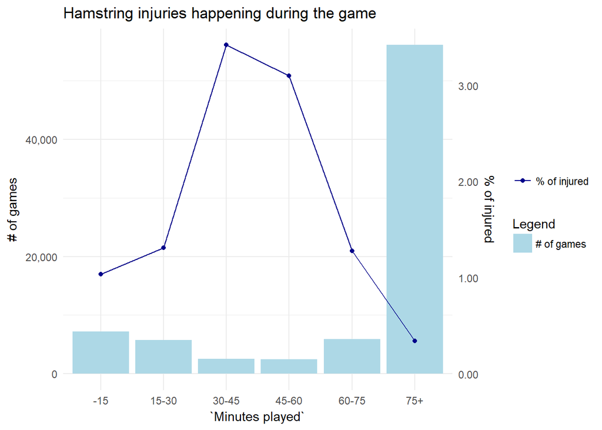

```r
hamstring_only %>%
  mutate(`Minutes played` = cut(minutes,
                                 breaks = c(0, 15, 30, 45, 60, 75,  Inf),
                                 include.lowest = T,
                                 labels = c("-15", "15-30", "30-45", "45-60", "60-75", "75+"))) %>%
  group_by(`Minutes played`) %>%
  summarize(game_count = n(),
  injury_count = (sum(injury_type != 0))) %>%
  ungroup() %>%
  mutate(injury_rate_pct = injury_count / game_count * 100) %>%
  f_breakdown_by_bins(s = "`Minutes played`")
```

#### Age, weight, height, bmi

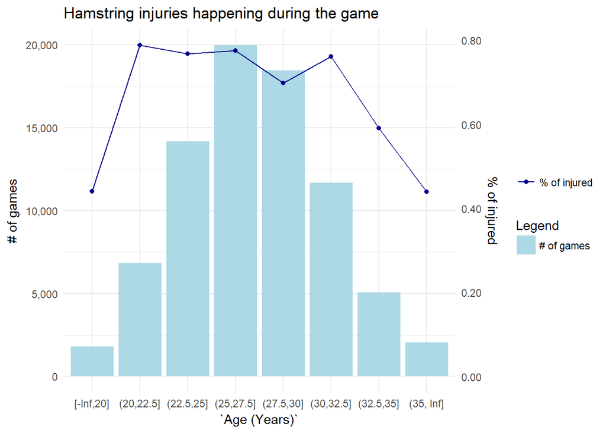

```r
hamstring_only %>%
  mutate(`Age (Years)` = cut(age_in_years,
                                 breaks = c(-Inf, 20, 22.5, 25, 27.5, 30, 32.5, 35, Inf),
                                 include.lowest = T)) %>%
  group_by(`Age (Years)`) %>%
  summarize(game_count = n(),
  injury_count = (sum(injury_type != 0))) %>%
  ungroup() %>%
  mutate(injury_rate_pct = injury_count / game_count * 100) %>%
  f_breakdown_by_bins(s = "`Age (Years)`")
```

Weight. TODO: Better categories needed

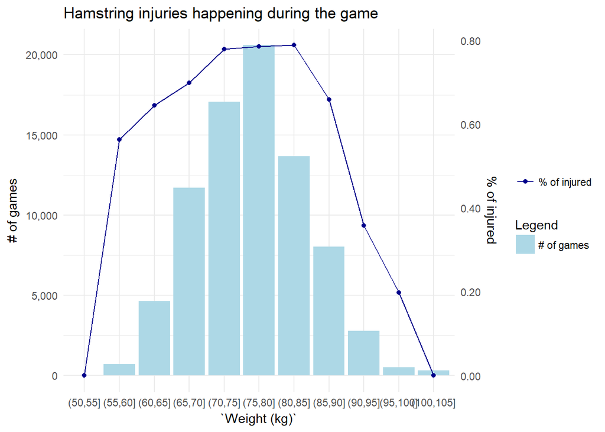

```r
hamstring_only %>%
  mutate(`Weight (kg)` = cut(`Weight (kg)`,
                              breaks = seq(0, 125, by = 5),
                              include.lowest = T)) %>%
  group_by(`Weight (kg)`) %>%
  summarize(game_count = n(),
  injury_count = (sum(injury_type != 0))) %>%
  ungroup() %>%
  mutate(injury_rate_pct = injury_count / game_count * 100) %>%
  f_breakdown_by_bins(s = "`Weight (kg)`")
```

Height:

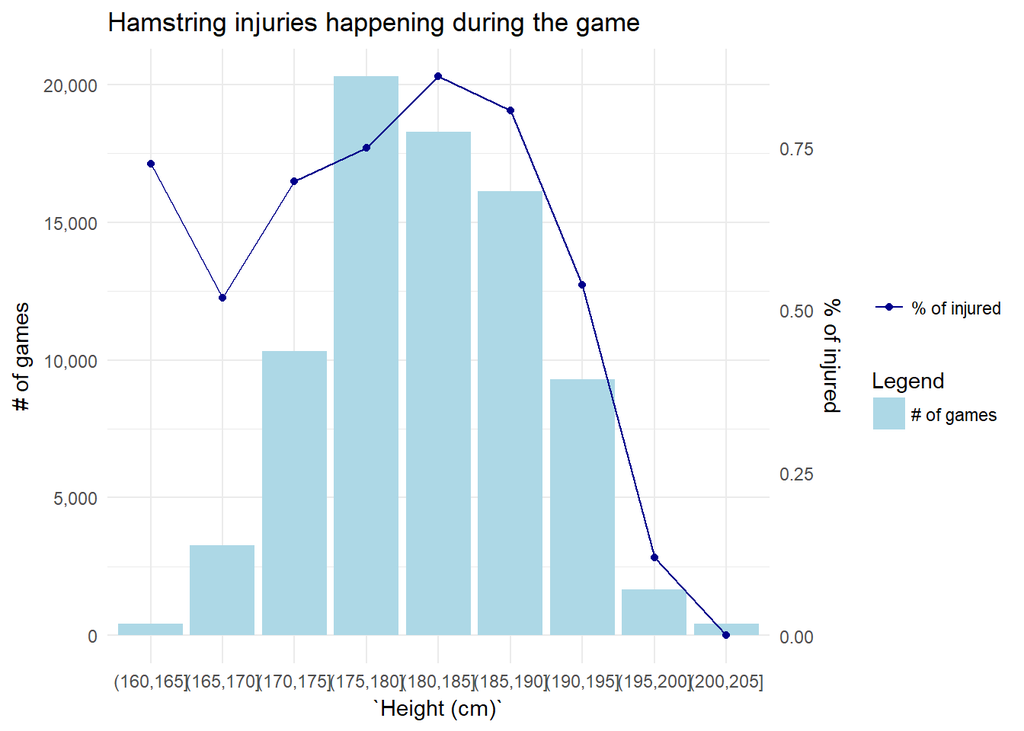

```r
hamstring_only %>%
  mutate(`Height (cm)` = cut(`Height (cm)`,
                              breaks = seq(0, 220, by = 5),
                              include.lowest = T)) %>%
  group_by(`Height (cm)`) %>%
  summarize(game_count = n(),
  injury_count = (sum(injury_type != 0))) %>%
  ungroup() %>%
  mutate(injury_rate_pct = injury_count / game_count * 100) %>%
  f_breakdown_by_bins(s = "`Height (cm)`")
```

BMI - does not seem to have any trend.

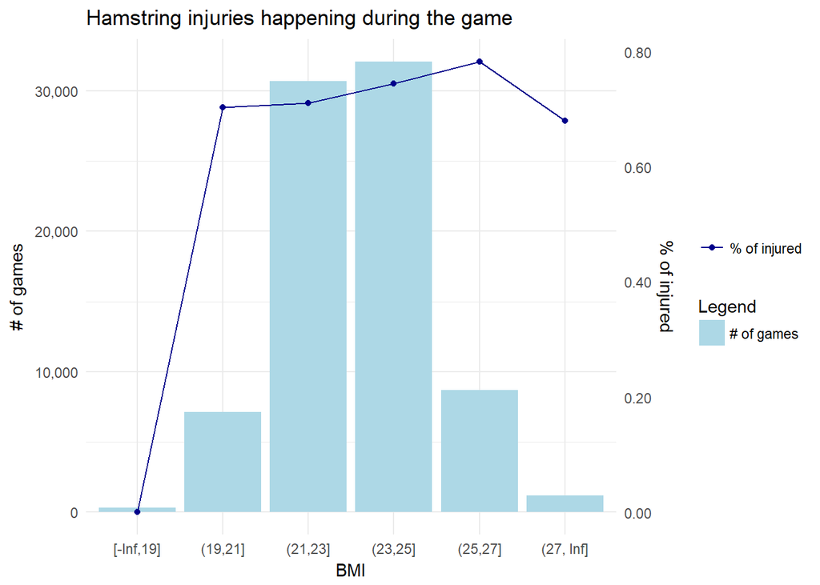

```r
hamstring_only %>%
  mutate(BMI = cut(bmi, breaks = c(-Inf, 19, 21, 23, 25, 27, Inf), include.lowest = T)) %>%
  group_by(BMI) %>%
  summarize(game_count = n(),
  injury_count = (sum(injury_type != 0))) %>%
  ungroup() %>%
  mutate(injury_rate_pct = injury_count / game_count * 100) %>%
  f_breakdown_by_bins(s = "BMI")
```

#### By Kick-off time

Maybe a slight impact…

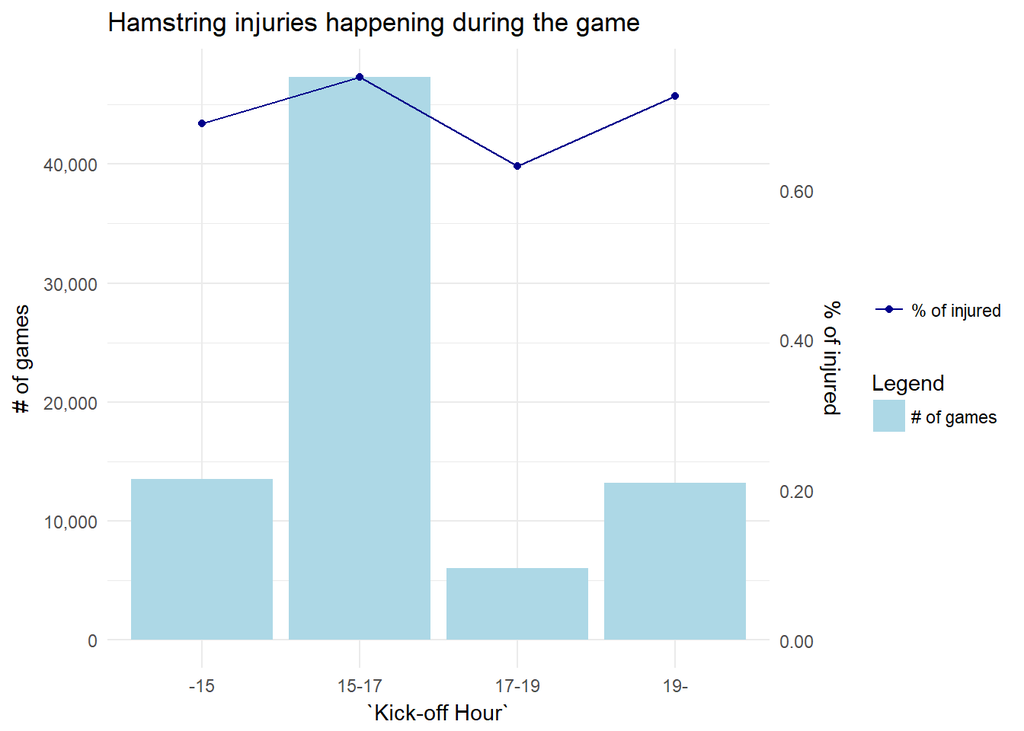

```r
hamstring_only %>%
  mutate(kick_off_hour = as.numeric(substr(`Kick-off`, 1, 2)) + as.numeric(as.numeric(substr(`Kick-off`, 4, 5)) > 30)) %>%
  mutate(`Kick-off Hour` = cut(kick_off_hour, breaks = c(0, 15, 17, 19, 24),
                                 include.lowest = T, labels = c("-15", "15-17", "17-19", "19-"))) %>%
  group_by(`Kick-off Hour`) %>%
  summarize(game_count = n(),
  injury_count = (sum(injury_type != 0))) %>%
  ungroup() %>%
  mutate(injury_rate_pct = injury_count / game_count * 100) %>%
  f_breakdown_by_bins(s = "`Kick-off Hour`")
```

#### by Year & Month

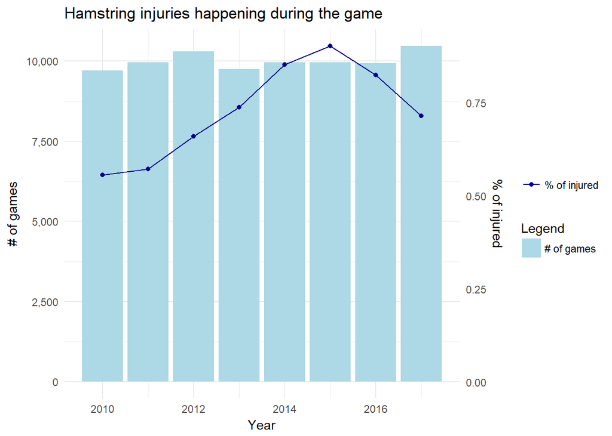

```r
hamstring_only %>%
  mutate(Year = year(Date)) %>%
  group_by(Year) %>%
  summarize(game_count = n(),
  injury_count = (sum(injury_type != 0))) %>%
  ungroup() %>%
  mutate(injury_rate_pct = injury_count / game_count * 100) %>%
  f_breakdown_by_bins(s = "Year")
```

# check against weather? or other variables

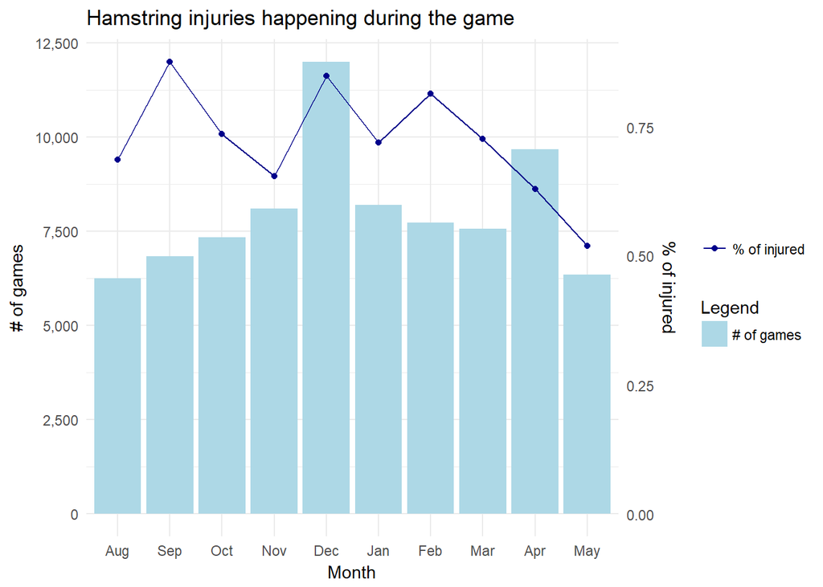

```r
Month_mapping <- data.frame(Month_Num = c(1:12), Month = c("Jan", "Feb", "Mar", "Apr", "May", "Jun",
                                                           "Jul", "Aug", "Sep", "Oct", "Nov", "Dec"),
                            Month_in_Season = c(6, 7, 8, 9, 10, 11, 12, 1, 2, 3, 4, 5))

hamstring_only %>%
  mutate(Month_Num = month(Date)) %>%
  left_join(Month_mapping, by = "Month_Num") %>%
  mutate(Month = reorder(Month, Month_in_Season)) %>%
  group_by(Month) %>%
  summarize(game_count = n(),
  injury_count = (sum(injury_type != 0))) %>%
  ungroup() %>%
  mutate(injury_rate_pct = injury_count / game_count * 100) %>%
  f_breakdown_by_bins(s = "Month")
```

#### Comparison with categorical variables

```r
f_breakdown_by_variable <- function(df, s) {
  df %>%
  group_by(!!as.name(s)) %>%
  summarize(game_count = n(),
            injury_count = (sum(injury_type != 0)),
            injury_rate_pct = injury_count / game_count * 100,
            avg_minutes_played = mean(minutes)) %>%
  ungroup() %>%
  arrange(-injury_rate_pct)
}
```

```r
f_breakdown_by_variable(hamstring_only, "Position")
```

```
## # A tibble: 5 x 5
##   Position   game_count injury_count injury_rate_pct avg_minutes_played
##   <chr>           <int>        <int>           <dbl>              <dbl>
## 1 Defender        26022          233          0.895                81.8
## 2 Attacker        16779          131          0.781                59.5
## 3 Midfielder      31163          213          0.684                69.0
## 4 Goalkeeper       6011            6          0.0998               89.3
## 5 ""                 89            0          0                    71.9
```

Note: Position is missing for a few records. Zero injuries. TODO: Investigate structure of missing data! Goalkeepers getting injured a lot less.

```r
f_breakdown_by_variable(hamstring_only, "Foot")
```

```
## # A tibble: 4 x 5
##   Foot  game_count injury_count injury_rate_pct avg_minutes_played
##   <chr>      <int>        <int>           <dbl>              <dbl>
## 1 Both        9879           96           0.972               66.4
## 2 Right      50911          361           0.709               73.9
## 3 Left       17865          120           0.672               73.2
## 4 ""          1409            6           0.426               67.8
```

Note: injury count is significantly lower when Foot is missing

TODO: create some groups based on country of birth / nationality ?

```r
f_breakdown_by_variable(hamstring_only, "Nationality")
```

```
## # A tibble: 101 x 5
##    Nationality   game_count injury_count injury_rate_pct avg_minutes_play~
##    <chr>              <int>        <int>           <dbl>             <dbl>
##  1 FYR Macedonia         13            1            7.69              71.1
##  2 Barbados              91            5            5.49              84.1
##  3 Belarus               24            1            4.17              49.2
##  4 Montenegro            52            2            3.85              46.1
##  5 Zimbabwe              28            1            3.57              32.2
##  6 New Zealand          170            6            3.53              80.8
##  7 Congo                 99            3            3.03              82.7
##  8 Ecuador              359            7            1.95              65.6
##  9 Costa Rica           154            3            1.95              58.0
## 10 Venezuela            108            2            1.85              76.5
## # ... with 91 more rows
```

#### Re-defining injury

Question: how many games to count? Question: what to do with days_till-injury?

```r
hamstring_only %>% glimpse()
```

```
## Observations: 80,064
## Variables: 36
## $ Date               <date> 2013-08-17, 2013-08-17, 2013-08-17, 2013-0...
## $ `Game week`        <dbl> 1, 1, 1, 1, 1, 1, 1, 1, 1, 1, 1, 1, 1, 1, 1...
## $ `Kick-off`         <chr> "16:00", "16:00", "16:00", "16:00", "16:00"...
## $ mid                <dbl> 1483415, 1483415, 1483415, 1483415, 1483415...
## $ pid                <int> 619, 1239, 2576, 2795, 2833, 2897, 2916, 29...
## $ `First name`       <chr> "Derek", "StÃ©phane", "Steve", "Aaron", "Ad...
## $ `Last name`        <chr> "Owusu Boateng", "SessÃ¨gnon", "Sidwell", "...
## $ minutes            <dbl> 65, 72, 90, 90, 90, 90, 90, 20, 90, 90, 90,...
## $ injured            <int> 0, 0, 0, 0, 0, 0, 0, 1, 0, 0, 0, 0, 0, 0, 0...
## $ injury_length      <int> 0, 0, 0, 0, 0, 0, 0, 26, 0, 0, 0, 0, 0, 0, ...
## $ injury_type        <chr> "0", "0", "0", "0", "0", "0", "0", "Hamstri...
## $ `Country of birth` <chr> "Ghana", "Benin", "England", "Northern Irel...
## $ Nationality        <chr> "Ghana", "Benin", "England", "Northern Irel...
```

[output cut: 23 more lines]

#### Fixing NAs & encode categicals

NAs:

```r
hamstring_only <- hamstring_only %>%
                    select(mid, pid, injured, Position, Foot, age_in_years, `Height (cm)`, `Weight (kg)`, bmi,
                                     starts_with("all_"))

hamstring_only <- hamstring_only %>% mutate(Position = ifelse(Position == "", "Missing", Position))
hamstring_only <- hamstring_only %>% mutate(Foot     = ifelse(Foot     == "", "Missing", Foot))
```

Encode categoricals:

```r
position_encoded <- hamstring_only %>%
                      select(mid, pid, Position) %>%
                      mutate(Position = paste("Position", Position, sep = "_")) %>%
                      mutate(i = 1) %>% tidyr::spread(key = Position, value = i, fill = 0) %>%
                      select(-Position_Goalkeeper) # assigning Goalkeeper as the "base value" for position

foot_encoded     <- hamstring_only %>%
                      select(mid, pid, Foot) %>%
                      mutate(Foot = paste("Foot", Foot, sep = "_")) %>%
                      mutate(i = 1) %>% tidyr::spread(key = Foot, value = i, fill = 0) %>%
                      select(-Foot_Right) # assigning Right as the "base value" for Foot

hamstring_only <- hamstring_only %>%
                    select(-Position, -Foot) %>%
                    left_join(position_encoded, by = c("mid", "pid")) %>%
                    left_join(foot_encoded,     by = c("mid", "pid"))
```

```r
#why is this data missing?
hamstring_only <- hamstring_only %>%
                    filter(!is.na(all_games_season) &
                           !is.na(all_games_28) &
                           !is.na(all_games_14) &
                           !is.na(all_games_4))
```

### Prediction

For now, let’s build two models: glm & rf. let’s see what signals can we pick up

Remove ids:

```r
hamstring_only <- hamstring_only %>%
                    select(-mid, -pid)
```

Caret needs the target to be a factor:

```r
hamstring_only$injured <- factor(hamstring_only$injured, levels = c("1", "0"), labels = c("Yes", "No"))

hamstring_only %>%
  count(injured)
```

```
## # A tibble: 2 x 2
##   injured     n
##   <fctr>  <int>
## 1 Yes       583
## 2 No      79456
```

```r
training_ratio <- 0.75

set.seed(93) #for reproducibility
train_indices <- createDataPartition(y = hamstring_only[["injured"]],
                                     times = 1,
                                     p = training_ratio,
                                     list = FALSE)

data_train <- hamstring_only[train_indices, ]
data_test  <- hamstring_only[-train_indices, ]

## FINAL TESTING TO BE DONE ON LAST YEAR's DATA
```

Setting up cross-validation:

```r
train_control <- trainControl(method = "cv",
                              number = 10,
                              classProbs = TRUE,
                              summaryFunction = twoClassSummary)
```

Simple logit:

```r
set.seed(93)
glm_model <- train(injured   ~ .,
                   method    = "glm",
                   family    = "binomial",
                   metric    = "ROC",
                   data      = data_train,
                   trControl = train_control)

summary(glm_model)
```

```
##
## Call:
## NULL
##
## Deviance Residuals:
##     Min       1Q   Median       3Q      Max
## -3.7932   0.1081   0.1213   0.1342   0.2160
##
## Coefficients:
##                       Estimate Std. Error z value Pr(>|z|)
## (Intercept)          4.654e+01  1.788e+01   2.602  0.00926 **
## age_in_years         1.235e-02  1.326e-02   0.931  0.35163
## `\\`Height (cm)\\`` -2.169e-01  9.805e-02  -2.212  0.02694 *
## `\\`Weight (kg)\\``  2.548e-01  1.167e-01   2.184  0.02899 *
## bmi                 -8.786e-01  3.885e-01  -2.262  0.02372 *
## all_mins_4          -1.704e-03  3.815e-03  -0.447  0.65509
## all_mins_28          1.308e-04  1.466e-03   0.089  0.92887
## all_games_14         1.162e-01  1.894e-01   0.614  0.53948
## all_games_season     9.543e-03  1.992e-02   0.479  0.63185
## all_games_4         -1.706e-02  3.152e-01  -0.054  0.95684
## all_games_28         6.310e-02  1.194e-01   0.529  0.59715
## all_mins_season      3.458e-05  2.537e-04   0.136  0.89160
## all_mins_14         -2.041e-03  2.335e-03  -0.874  0.38209
## Position_Attacker   -2.053e+00  5.258e-01  -3.904 9.47e-05 ***
## Position_Defender   -2.222e+00  5.124e-01  -4.336 1.45e-05 ***
## Position_Midfielder -2.063e+00  5.225e-01  -3.948 7.87e-05 ***
## Position_Missing     8.442e+00  1.700e+02   0.050  0.96039
## Foot_Both           -1.816e-01  1.404e-01  -1.293  0.19585
## Foot_Left            1.484e-01  1.229e-01   1.208  0.22718
## Foot_Missing         3.647e-01  4.549e-01   0.802  0.42276
## ---
## Signif. codes:  0 '***' 0.001 '**' 0.01 '*' 0.05 '.' 0.1 ' ' 1
##
## (Dispersion parameter for binomial family taken to be 1)
##
##     Null deviance: 5183.0  on 60029  degrees of freedom
## Residual deviance: 5105.4  on 60010  degrees of freedom
## AIC: 5145.4
##
## Number of Fisher Scoring iterations: 14
```

```r
glm_prediction_probs <- predict.train(glm_model, newdata = data_test, type = "prob")
test_truth <- data_test$injured
```

Help functions:

```r
fun_calc_auc <- function(prediction_probs, truth) {

  rocr_prediction <- ROCR::prediction(prediction_probs$Yes, truth)
  AUC <- ROCR::performance(rocr_prediction, "auc")@y.values[[1]]

  return(AUC)
}
```

```r
fun_roc_create <- function(prediction_probs, truth, AUC= NULL, model= NULL) {

  min_prob <- min(prediction_probs$Yes)
  max_prob <- max(prediction_probs$Yes)

  thresholds <- seq(0, max_prob, by = (max_prob - min_prob) / 100)

  true_positive_rates <- rep(0, length(thresholds))
  false_positive_rates <- rep(0, length(thresholds))

  for (ix in 1:length(thresholds)) {
    thr <- thresholds[ix]
    test_prediction <- ifelse(prediction_probs$Yes > thr, "Yes", "No")
    test_prediction <- factor(test_prediction, levels = c("Yes", "No"))
    cm <- as.matrix(confusionMatrix(data = test_prediction, reference = truth))
    true_positive_rates[ix] <- cm[1, 1] / (cm[1, 1] + cm[2, 1])
    false_positive_rates[ix] <- cm[1, 2] / (cm[1, 2] + cm[2, 2])
  }

  manual_roc <- data.table("threshold" = thresholds,
                           "true_positive_rate" = true_positive_rates,
                           "false_positive_rate" = false_positive_rates)

  s_title <- ifelse(is.null(model), "", paste("ROC curve for Model:", model, sep = " "))
  s_subtitle <- ifelse(is.null(AUC), "", paste("AUC =", round(AUC, 2), sep = " "))

  ggplot(data = manual_roc,
         aes(x = false_positive_rate, y = true_positive_rate, color = threshold)) +
    geom_point() +
    geom_abline(intercept = 0, slope = 1,  linetype = "dotted", col = "black") +
    labs(title = s_title, subtitle = s_subtitle)
}
```

```r
fun_calibration_create <- function(prediction_probs, truth, model= NULL) {

  truth_numeric <- ifelse(truth == "Yes", 1, 0)
  score <- prediction_probs$Yes

  actual_vs_predicted <- data.table(actual = truth_numeric,
                                    predicted = score)

  actual_vs_predicted[, score_category := cut(predicted,
                                      seq(0, .25, 0.005),
                                      include.lowest = TRUE)]

  calibration <- actual_vs_predicted[, .(mean_actual = mean(actual),
                                         mean_predicted = mean(predicted),
                                         num_obs = .N),
                                     keyby = .(score_category)]

  s_title <- ifelse(is.null(model), "", paste("Calibration plot for Model:", model, sep = " "))

  ggplot(calibration,
         aes(x = mean_actual, y = mean_predicted, size = num_obs)) +
    geom_point() +
    geom_abline(intercept = 0, slope = 1, linetype = "dashed") +
    ylim(0, 0.25) + xlim(0, 0.25) +
    labs(title = s_title)
}
```

```r
glm_AUC <- fun_calc_auc(glm_prediction_probs, test_truth)
glm_ROC <- fun_roc_create(glm_prediction_probs, test_truth, glm_AUC, "glm")
glm_calibration <- fun_calibration_create(glm_prediction_probs, test_truth, "glm")
```

Random Forest - this will be our benchmark model:

```r
train_Control <- trainControl(method = "CV",
                              number = 10,
                              classProbs = TRUE,
                              summaryFunction = twoClassSummary,
                              selectionFunction = "best")

tune_Grid_rf <- data.frame(mtry = c(2:7))
#round(sqrt(ncol(data_train)-1))

set.seed(93)
rf_500_fit <- train(injured ~ .,
                   data = data_train,
                   method = "rf",
                   metric = "ROC",
                   trControl = train_Control,
                   tuneGrid = tune_Grid_rf ,
                   ntree = 250,
                   importance = T)

print(rf_500_fit)
```

```
## Random Forest
##
## 60030 samples
##    19 predictor
##     2 classes: 'Yes', 'No'
##
## No pre-processing
## Resampling: Cross-Validated (10 fold)
## Summary of sample sizes: 54026, 54028, 54026, 54027, 54027, 54028, ...
## Resampling results across tuning parameters:
##
##   mtry  ROC        Sens  Spec
##   2     0.5489601  0     1
##   3     0.5500425  0     1
##   4     0.5458713  0     1
##   5     0.5471773  0     1
##   6     0.5589614  0     1
##   7     0.5494556  0     1
##
## ROC was used to select the optimal model using the largest value.
## The final value used for the model was mtry = 6.
```

```r
rf_500_prediction_probs <- predict.train(rf_500_fit, newdata = data_test, type = "prob")
```

```r
rf_500_AUC <- fun_calc_auc(rf_500_prediction_probs, test_truth)
rf_500_ROC <- fun_roc_create(rf_500_prediction_probs, test_truth, rf_500_AUC, "glm")
rf_500_calibration <- fun_calibration_create(rf_500_prediction_probs, test_truth, "glm")
```

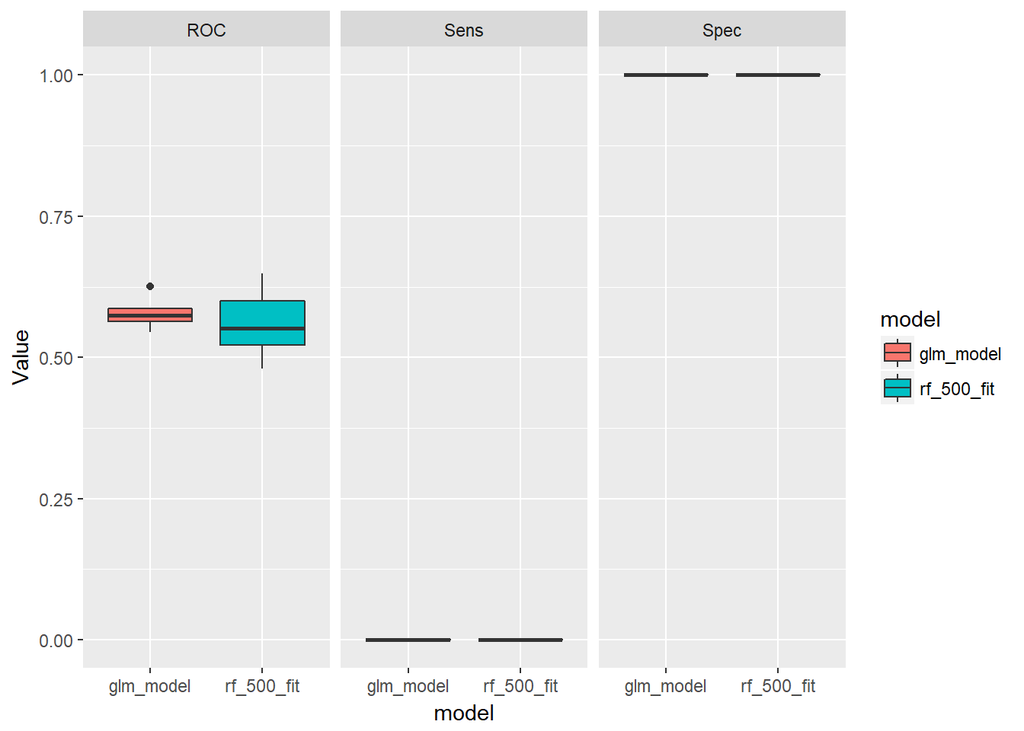

```r
resamples_object <- resamples(list("glm_model" = glm_model,
                                   "rf_500_fit" = rf_500_fit))

resamples_object$values %>%
  tidyr::gather(key= "Resample", factor_key = F) %>%
  setnames(c("Fold", "Model~Metric", "Value")) %>%
  mutate(model = stringr::str_split(`Model~Metric`, "~", simplify = T)[,1],
         metric = stringr::str_split(`Model~Metric`, "~", simplify = T)[,2]) %>%
  mutate(model = factor(model, levels = c("glm_model", "rf_500_fit"))) %>%
  ggplot(aes(x= model, y= Value, fill = model)) +
    geom_boxplot() +
    facet_grid(~metric)
```